# (fordgobike-tripdata Exploration Title)

## Cleaning Step:

```python
#create a copy of our dataset
df_copy= df.copy()
```

```python
#Change the datatype of start_time and end_time to datetime using Pandas's to_datetime method
df_copy['start_time']= pd.to_datetime(df_copy['start_time'])
df_copy['end_time']= pd.to_datetime(df_copy['end_time'])
```

```python
#Creating new column called 'age' by calculating the difference between 2019 and member_birth_year
#The reason behind choosing 2019 is, its the year were this dataset is published (file name 201902, 2019 is the year)
df_copy['age']= 2019-df_copy.member_birth_year
```

```python
#drop unneeded Columns in our data exploration
df_copy.drop(['start_station_id', 'start_station_latitude', 'start_station_longitude', 'end_station_latitude',
         'end_station_longitude','end_station_id'], axis=1, inplace= True)
```

```python
df_copy.info()
```

```
<class 'pandas.core.frame.DataFrame'>
RangeIndex: 183412 entries, 0 to 183411
Data columns (total 11 columns):
 #   Column                   Non-Null Count   Dtype
---  ------                   --------------   -----
 0   duration_sec             183412 non-null  int64
 1   start_time               183412 non-null  datetime64[ns]
 2   end_time                 183412 non-null  datetime64[ns]
 3   start_station_name       183215 non-null  object
 4   end_station_name         183215 non-null  object
 5   bike_id                  183412 non-null  int64
 6   user_type                183412 non-null  object
 7   member_birth_year        175147 non-null  float64
 8   member_gender            175147 non-null  object
 9   bike_share_for_all_trip  183412 non-null  object
 10  age                      175147 non-null  float64
dtypes: datetime64[ns](2), float64(2), int64(2), object(5)
memory usage: 15.4+ MB
```

```python
#Also create a new column called age_class that classify member based on his age.
#Source of this classifications:
#https://www.semanticscholar.org/paper/Human-Age-Group-Classification-Using-Facial-Bhat-V.K.Patil/19ddb412336ce633c1fe21544605c7bd65ff8d66
def cal_age (row):
    if (0< row['age'] < 17) :
        return 'child'
    elif (16< row['age'] <31) :
        return 'young adults'
    elif (30< row['age'] <46) :
        return 'middle-aged Adults'
    elif row['age']>45:
        return 'old-aged'
    else:
        return None

df_copy['age_class'] = df_copy.apply (lambda row: cal_age(row), axis=1)
```

```python
df_copy.info()
```

```
<class 'pandas.core.frame.DataFrame'>
RangeIndex: 183412 entries, 0 to 183411
Data columns (total 12 columns):
 #   Column                   Non-Null Count   Dtype
---  ------                   --------------   -----
 0   duration_sec             183412 non-null  int64
 1   start_time               183412 non-null  datetime64[ns]
 2   end_time                 183412 non-null  datetime64[ns]
 3   start_station_name       183215 non-null  object
 4   end_station_name         183215 non-null  object
 5   bike_id                  183412 non-null  int64
 6   user_type                183412 non-null  object
 7   member_birth_year        175147 non-null  float64
 8   member_gender            175147 non-null  object
 9   bike_share_for_all_trip  183412 non-null  object
 10  age                      175147 non-null  float64
 11  age_class                175147 non-null  object
dtypes: datetime64[ns](2), float64(2), int64(2), object(6)
memory usage: 16.8+ MB
```

### What is/are the main feature(s) of interest in your dataset?

> there are multiple intrested features
> - Age, Gender, trip duration, station's names, user_type all will come helpfull in the process

### What features in the dataset do you think will help support your investigation into your feature(s) of interest?

> - Age or member_birth_year, will show us the distribution of our member's age.
>   - Gender will till us the distribution of our member's gender.
>   - user_type weather most of our users are subscribers or Customers.
>   - duration in second, weather subscriber take more time or customers.

## Univariate Exploration

> In this section, investigate distributions of individual variables. If you see unusual points or outliers, take a deeper look to clean things up and prepare yourself to look at relationships between variables.

> Make sure that, after every plot or related series of plots, that you include a Markdown cell with comments about what you observed, and what you plan on investigating next.

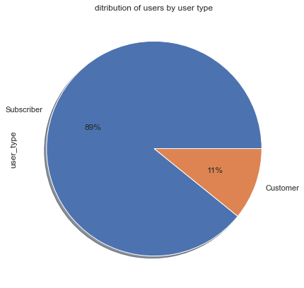

```python
#plot a pie chart that shows the distribution of members between 'subscribers' and 'customer'.
plot = df_copy.user_type.value_counts().plot.pie(figsize=(7, 7),autopct='%.f%%', shadow=True)
plot.set_title('ditribution of users by user type')
```

**Observations found:**

- It appears that 89% of members are subscribers and only 11% are customers.
- Will investigate the distribution of their user_type and age later on.

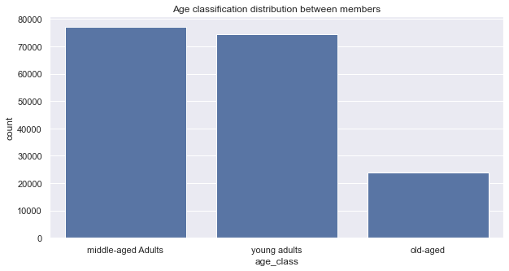

```python
plt.figure(figsize = [10, 5]);
#plotting a bar chart to see the age_class distribtion in this dataset using seaborn countplot method.
sb.countplot(data=df_copy, x='age_class',order= df_copy.age_class.value_counts().index,color = sb.color_palette()[0]).set_title(
    'Age classification distribution between members');
```

**Observations found:**

- There is not a single record that has age less than 17 which is odd considering that they represent 14% of San Francisco population according to this source:https://www.census.gov/quickfacts/sanfranciscocountycalifornia
- Will investigate deeper for the age distribution.

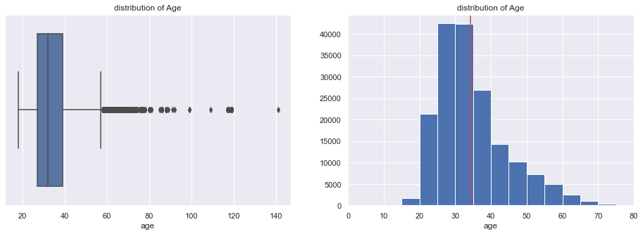

```python
#setting the fiqure size.
plt.figure(figsize = [16, 5]);

#plotting the first plot.
plt.subplot(1, 2, 1);

#plotting a box plot for the distribution of age in the dataset and notice if there is any outliers.
sb.boxplot(data= df_copy, x='age').set_title('distribution of Age');

#plotting the second plot.
plt.subplot(1,2,2);

#setting the histogram bins by using numpy arange method, 0 is the minimum, df[age].max is the maximum, 5 is the bin size.
#which will stored in bin_edges variable.
bin_edges = np.arange(0, df_copy['age'].max()+5, 5);

plt.hist(df_copy['age'], bins = bin_edges, );

#remove mosrt of the outliers from the histogram chart by setting the limit of x axis to 80.
plt.xlim((0,80));

#set the title and x label of the histogram chart.
plt.title('distribution of Age');
plt.xlabel('age');

#plot a red line in the histogram chart that represent the mean value of age.
plt.axvline(df_copy.age.mean() ,color='r');
```

```python
print('mean age= ',df_copy.age.mean())
len(df_copy.query('age >24 and age <41'))/df.shape[0]
```

```
mean age=  34.19356312126385
```

```
0.6283612849759013
```

**Observations found:**

- From the two plots above, we can clearly see that more than 60% percent of our members are between 25 and 40 years old, which can be explained by https://www.infoplease.com/us/census/california/san-francisco/demographic-statistics, which says that almost 40.4% percent of San Francisco population are between 25 and 44.
- The histogram chart is more likely a right skewed than a normal, meaning, the mod is less than the mean, which is explained by the red line in the bar chart that represent the mean age in this data set.

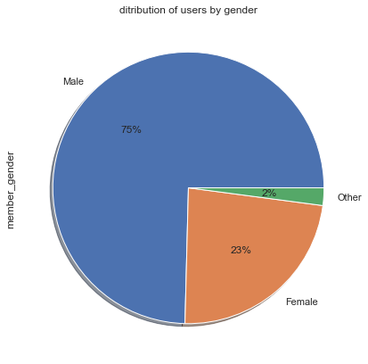

```python
#plot a pie chart that shows the distribution of gender between members.
plot = df_copy.member_gender.value_counts().plot.pie(figsize=(7, 7),autopct='%.f%%', shadow=True);
plot.set_title('ditribution of users by gender');
```

**Observations found:**

- The gender distribution between members is 75% percent of them are male, and only 23% are female, three times more than females, it is very odd especially because according to this source: https://worldpopulationreview.com/us-cities/san-francisco-ca-population , the percentage of female in San Francisco is 49% whereas male are 51% which nowhere close to what this dataset says.

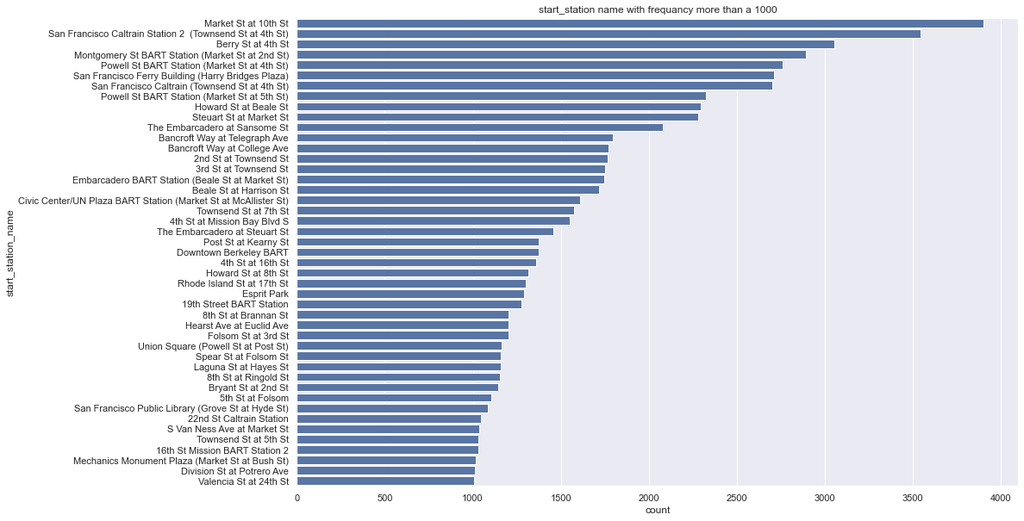

```python
#source of filter method 'https://stackoverflow.com/questions/13167391/filtering-grouped-dataframe-in-pandas'
#take only start_station_name that have more than 1000 records
filtered_station = df_copy.groupby(['start_station_name']).filter(lambda x: len(x) >= 1000 )


#plotting a bar chart to see the age_class distribtion in this dataset using seaborn countplot method.
sb.countplot(data=filtered_station, y='start_station_name',order= filtered_station.start_station_name.value_counts().index,color = sb.color_palette()[0]).set_title(
    'start_station name with frequancy more than a 1000');
sb.set(rc={'figure.figsize':(15,10)})
```

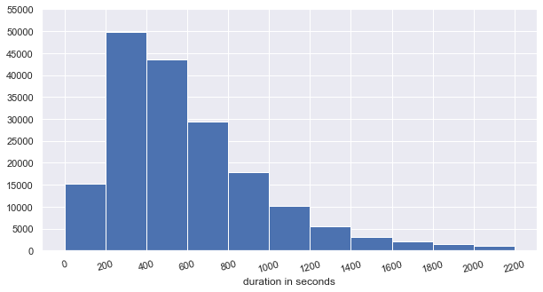

```python
plt.figure(figsize = [10, 5]);

#plot a histogram for the duration of the trip, capped to 2200 seconds only.
plt.hist(df_copy['duration_sec'],bins=[0,200,400,600,800,1000,1200,1400,1600,1800,2000,2200],rwidth=1)


plt.xticks([0,200,400,600,800,1000,1200,1400,1600,1800,2000,2200],rotation=15);
plt.xlabel('duration in seconds');
plt.yticks([0,5000,10000,15000,20000,25000,30000,35000,40000,45000,50000,55000]);
```

```python
len(df_copy.query(' duration_sec > 199 and duration_sec < 801'))/df_copy.shape[0]
```

```
0.6699289032342486
```

**Observations found:**

- We can clearly see that most of the trips(67%) are between 200 and 800 seconds (3 to 13 mintues) and the counter for trips more than 800 start to go down fast.
- plan to investigate if there is any relationship between trip lenght and gender.

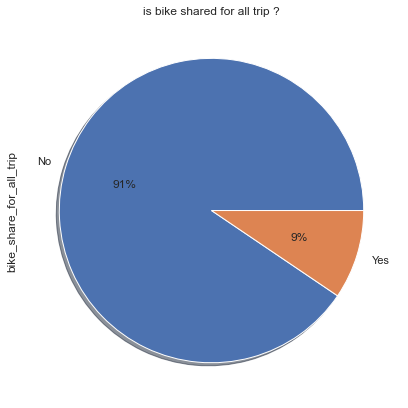

```python
plot = df_copy.bike_share_for_all_trip.value_counts().plot.pie(figsize=(7, 7),autopct='%.f%%', shadow=True);
plot.set_title('is bike shared for all trip ?');
```

**Observations found:**

- 91% of the bikes are not shared for all trip

### Discuss the distribution(s) of your variable(s) of interest. Were there any unusual points? Did you need to perform any transformations?

> The distribution of gender is odd, also there not a single record with age less than 17!. didn't need to do any transformation, only filtering the station name to ba able to see the top station name

### Of the features you investigated, were there any unusual distributions? Did you perform any operations on the data to tidy, adjust, or change the form of the data? If so, why did you do this?

> The gender distribution is 75% male and only 23% female, its unusual.

## Bivariate Exploration

> In this section, investigate relationships between pairs of variables in your data. Make sure the variables that you cover here have been introduced in some fashion in the previous section (univariate exploration).

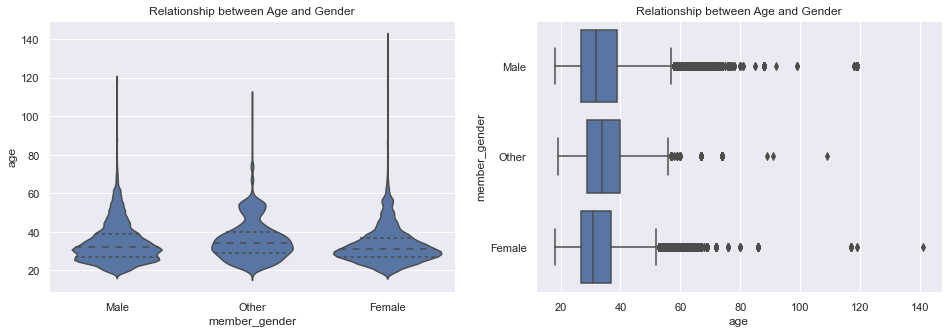

```python
#setting the fiqure size.
plt.figure(figsize = [16, 5]);

#plotting the first plot.
plt.subplot(1, 2, 1);

#plotting a violin plot for the relationship between age and gender.
sb.violinplot(data= df_copy, x='member_gender',y='age', color= sb.color_palette()[0],inner='quartile').set_title(
    'Relationship between Age and Gender');

#plotting the second plot.
plt.subplot(1,2,2);

#plotting a box plot for the relationship between age and gender.
sb.boxplot(data=df_copy,y='member_gender',x='age', color= sb.color_palette()[0]).set_title(
    'Relationship between Age and Gender');
```

```python
print('average age for Male: ',df_copy.loc[df_copy['member_gender']=='Male'].age.mean())
print('average age for Female: ',df_copy.loc[df_copy['member_gender']=='Female'].age.mean())

print('median age for Male: ',df_copy.loc[df_copy['member_gender']=='Male'].age.median())
print('median age for Female: ',df_copy.loc[df_copy['member_gender']=='Female'].age.median())
```

```
average age for Male:  34.45160006429342
average age for Female:  33.2174615610616
median age for Male:  32.0
median age for Female:  31.0
```

The box plot and violin plot shows the relationship between gender and age in this dataset.

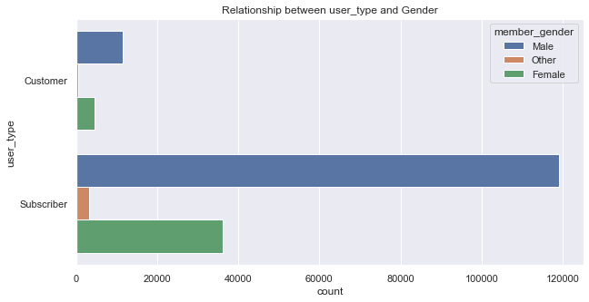

```python
plt.figure(figsize = [10, 5]);
#plot a bar chart for the relationship between gender and user_type
sb.countplot(data = df_copy, y = 'user_type', hue = 'member_gender' ).set_title('Relationship between user_type and Gender');
```

**Observations found:**

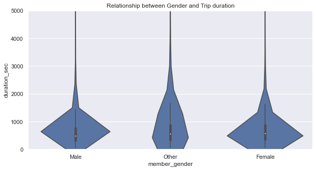

```python
plt.figure(figsize = [10, 5]);

#plot a box plot for the relationship between gender and duration.
box_gen= sb.violinplot(data=df_copy,x='member_gender',y='duration_sec', color= sb.color_palette()[0],)

#set a limit for the duration sec to avoid very extreme values.
box_gen.set_ylim([0, 5000]) ;
box_gen.set_title('Relationship between Gender and Trip duration');
```

**Observations found:**

- The gender has no effect in trip duration in female and male, shape looks similar.
- Whereas in 'other', the distribution looks higher to 3000 seconds.

```
0.006026742656500267
```

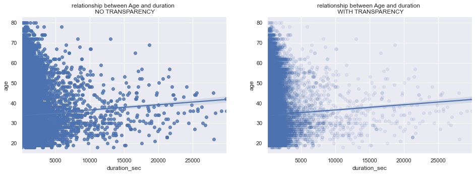

```python
#set the fiqure size.
plt.figure(figsize = [16, 5]);

#Remove extreme values first to plot a proper scatterplot.
df_noextreme= df_copy.query('age <81 and duration_sec < 30000')

#plot the first scatter plot between age and duration without transperency.
plt.subplot(1,2,1)
sb.regplot(data=df_noextreme,y='age',x='duration_sec').set_title('relationship between Age and duration \n NO TRANSPARENCY');

#plot the first scatter plot between age and duration without transperency.
plt.subplot(1,2,2)
sb.regplot(data=df_noextreme,y='age',x='duration_sec',scatter_kws={'alpha':1/10}).set_title('relationship between Age and duration \n WITH TRANSPARENCY');

#print the correlation coefficient between age and duration
print(df_copy.duration_sec.corr(df_copy.age));
```

**Observations found:**

- With correlation coefficient beeing 0.006, almost a zero, there is no relationship between Age and duration.
- Although the LEFT PLOT is telling us that older people get a higher duration trips, but we can clearly see from the RIGHT PLOT that they are an extreme values and not many data points has a higher duration.
- And Acutally from the RIGHT PLOT, we can see that younger people have a longer trip duration in comparsion to older people (space of dark area is wider for young people).
- Transparency is an important tool in scatter plot.

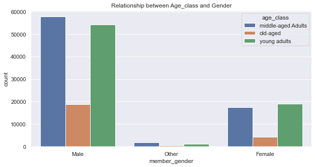

```python
plt.figure(figsize = [10, 5]);
#plot the relationship bwtween gender and age_class
sb.countplot(data= df_copy, x='member_gender',hue='age_class',).set_title('Relationship between Age_class and Gender');
```

```python
#Calculate the porpotion size for each age_class based on gender in the dataset.
x=df_copy.groupby(['member_gender','age_class']).size()/df_copy.shape[0]
print(df_copy.groupby(['member_gender','age_class']).size()/df_copy.shape[0])

#Calculate the porpotion size of young adults in Female.
print('young_adults porpotion in Female= ',x.Female[2]/(x.Female[0]+x.Female[1]+x.Female[2]))

#Calculate the porpotion size of young adults in Female.
print('young_adults porpotion in Male= ',x.Male[2]/(x.Male[0]+x.Male[1]+x.Male[2]))

#Calculate the porpotion size of young adults in Female.
print('old_aged porpotion in Female= ',x.Female[1]/(x.Female[0]+x.Female[1]+x.Female[2]))

#Calculate the porpotion size of young adults in Female.
print('Old-aged porpotion in Male= ',x.Male[1]/(x.Male[0]+x.Male[1]+x.Male[2]))
```

```
member_gender  age_class
Female         middle-aged Adults    0.095414
               old-aged              0.023570
               young adults          0.103706
Male           middle-aged Adults    0.314287
               old-aged              0.102894
               young adults          0.295155
Other          middle-aged Adults    0.010223
               old-aged              0.003151
               young adults          0.006537
dtype: float64
young_adults porpotion in Female=  0.46569875624326706
young_adults porpotion in Male=  0.41434814888519794
old_aged porpotion in Female=  0.10584173930075409
Old-aged porpotion in Male=  0.1444458901960184
```

- **young adults** = 17-30 Age
- **middle-aged adults** = 31-45 Age
- **old_aged** = Above 45 Age

**Observations found:**  
With the clustered bar that shows the relationship between gender and age_class, and the calculation above that shows the proportion of each age_class based on gender in dataset we can say:

- 1- young-adults represent 46% of Female gender.
- 2- young-adults represent only 41% of Male gender.
- 3- for old_aged, its only represent 10% in Female whereas it represent 15% in Male.
- 4- Middle-aged adults is the highest category the male has, whereas Female young-adults is the highest.

### Did you observe any interesting relationships between the other features (not the main feature(s) of interest)?

> No

## Multivariate Exploration

> Create plots of three or more variables to investigate your data even further. Make sure that your investigations are justified, and follow from your work in the previous sections.

```python
#source: https://til.tafkas.net/posts/seaborn-correlation-coefficient-on-facetgrid/

from scipy import stats
#method to print the correlation coefficient in each scatter plot.
def corrfunc(x, y, **kws):
    r, _ = stats.pearsonr(x, y)
    ax = plt.gca()
    ax.annotate("r = {:.2f}".format(r),
                xy=(.1, .9), xycoords=ax.transAxes)
```

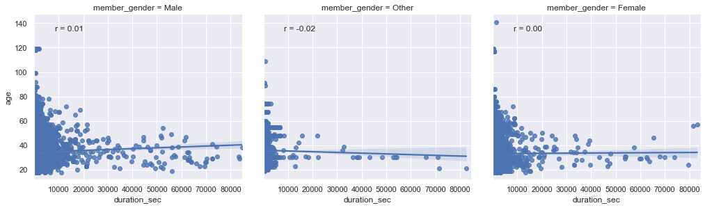

```python
#plot a multivariate plot showing a scetter plot between age and duration based on gender.
g= sb.FacetGrid(data=df_copy,col='member_gender');
g.map(sb.regplot,'duration_sec','age');
g.map(corrfunc, 'duration_sec', 'age');
g.fig.set_size_inches(15,5);
```

**Observations found:**

- Although the correlation coefficient is close to zero(-0.02), but we can see a nigative relationship between age and duration for 'other' gender.
- Female gender has a zero(0.00xxx) corr, which means there is no relationship between female and age in duration trip.
- There is slight positive relationship between age and duration in regarding the Male gender.

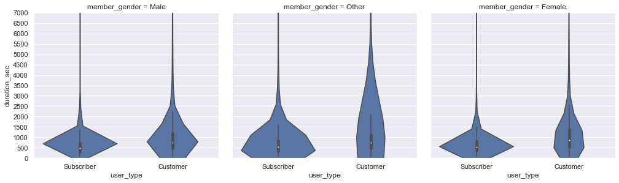

```python
#plot a multivariate plot showing the relationship between user_type and duration based on gender.
g2= sb.FacetGrid(data=df_copy,col='member_gender');
g2.map(sb.violinplot,'user_type','duration_sec',order=['Subscriber','Customer'],);
g2.fig.set_size_inches(15,5);

#set a limit for y axis to remove extreme values
g2.set(ylim=(0,7000));
g2.set(yticks=([0,500,1000,1500,2000,2500,3000,3500,4000,4500,5000,5500,6000,6500,7000]))
```

**Observations found:**

- Customers trip duration in all gender tend to be longer in comparison to Subscribers.
- 'Other' has the longest trip duration distribution.

### Talk about some of the relationships you observed in this part of the investigation. Were there features that strengthened each other in terms of looking at your feature(s) of interest?

> 1- We can see a nigative relationship between age and duration for 'other' gender.  
> 2- Female gender has a zero(0.00xxx) corr, which means there is no relationship between female and age in duration trip.  
> 3- There is slight positive relationship between age and duration in regarding the Male gender.  
> 4- Customers trip duration in all gender tend to be longer in comparison to Subscribers.  
> 5- 'Other' has the longest trip duration distribution.

### Were there any interesting or surprising interactions between features?

> No.

> At the end of your report, make sure that you export the notebook as an html file from the `File > Download as... > HTML` menu. Make sure you keep track of where the exported file goes, so you can put it in the same folder as this notebook for project submission. Also, make sure you remove all of the quote-formatted guide notes like this one before you finish your report!

```python
#saving our cleaned and merged dataset: -

#         * I comment this line to avoid saving the file multiple times.

#df_copy.to_csv('fordgobike-cleaned.csv', index=True)
```